# Translating Antonsen 2020 to Darwin Core

# Introduction

This is an [R Markdown](http://rmarkdown.rstudio.com) Notebook for converting the data found in the following reference to Darwin Core format for upload into [GBIF](https://gbif.org/):

[Antonsen, A.K. Spatiotemporal Dynamics of Butterflies and their Floral Resources. North Dakota State University. ProQuest Dissertations & Theses, 2020. 28026937.](https://www.proquest.com/openview/513b62aa7e72c32b625ded0127ba3c63/1?pq-origsite=gscholar&cbl=44156)

[Adrienne K Antonsen, Katherine C Kral-O’Brien, Torre J Hovick, Ryan F Limb, Benjamin A Geaumont, Jason P Harmon, Intra-annual Spatiotemporal Dynamics of the Monarch Butterfly (Lepidoptera: Danaidae), Regal Fritillary (Lepidoptera: Heliconiinae), and Their Floral Resources in North Dakota, United States, Annals of the Entomological Society of America, Volume 114, Issue 6, November 2021, Pages 727–737.](https://doi.org/10.1093/aesa/saab013)

## Introduction to project data

# Setup

Call the necessary libraries and variables. Suppresses loading messages.

```r
library(magrittr)                       # To use %<>% pipes
suppressMessages(library(dplyr))        # To clean input data
library(stringr)                        # To clean input data
library(digest)                         # To generate hashes
```

# Read source data

Read in source csv tables

```r
input_butterfly <- "inputs/butterfly_data.csv"
input_flower <- "inputs/flower_data.csv"
input_site_coords <- "inputs/site_coordinates.csv"
input_site_vegetation <- "inputs/vegetation_data.csv"
input_species_codes <- "inputs/species_codes.csv"
input_site_name_mappings <- "inputs/site_name_mappings.csv"

butterfly_data <- read.csv(input_butterfly)
flower_data <- read.csv(input_flower)
site_coords_data <- read.csv(input_site_coords)
site_vegetation_data <- read.csv(input_site_vegetation)
species_codes_data <- read.csv(input_species_codes)
site_name_mappings <- read.csv(input_site_name_mappings)

species_codes_data <- rbind(
  species_codes_data,
  data.frame(
    Code = "grass",
    Scientific.Name = "Poaceae",
    Common.Name = "True grasses"
  )
)

species_codes_data <- rbind(
  species_codes_data,
  data.frame(
    Code = "Grass",
    Scientific.Name = "Poaceae",
    Common.Name = "True grasses"
  )
)

species_codes_data <- rbind(
  species_codes_data,
  data.frame(
    Code = "GRASS",
    Scientific.Name = "Poaceae",
    Common.Name = "True grasses"
  )
)
# preview pretty table
#knitr::kable(head(butterfly_data))
```

# Clean data

```r
#standardize site names using mappings
butterfly_data$Original.Site <- butterfly_data$Site
butterfly_data$Site <- site_name_mappings$Clean.Site.Abbr[
  match(butterfly_data$Site, site_name_mappings$Dirty.Site)
]

flower_data$Original.Site <- flower_data$Site
flower_data$Site <- site_name_mappings$Clean.Site.Abbr[
  match(flower_data$Site, site_name_mappings$Dirty.Site)
]

site_coords_data$Original.Site <- site_coords_data$Site.Name
site_coords_data$Site.Name <- site_name_mappings$Clean.Site.Abbr[
  match(site_coords_data$Site.Name, site_name_mappings$Dirty.Site)
]

site_vegetation_data$Original.Site <- site_vegetation_data$Site
site_vegetation_data$Site <- site_name_mappings$Clean.Site.Abbr[
  match(site_vegetation_data$Site, site_name_mappings$Dirty.Site)
]

# Does BEN White Horse Hill NWR = BEN Sully's Lake NWR = BEN Sully's Hill NWR?

#clean specific cells
flower_data$Date[
  flower_data$Site == "CAS Alice WPA 1" &
  flower_data$Code %in% c("FLTDS-A0176", "FLTDS-A0177", "FLTDS-A0178", "FLTDS-A0179", "FLTDS-A0180", "FLTDS-A0181", "FLTDS-A0182")
] <- "8/22/17"

flower_data$Code[
  flower_data$Site == "CAS Alice WPA 1" &
  flower_data$Code %in% c("FLTDS-A0176", "FLTDS-A0177", "FLTDS-A0178", "FLTDS-A0179", "FLTDS-A0180", "FLTDS-A0181", "FLTDS-A0182")
] <- "FLTDS-A0175"

flower_data$Code[
  flower_data$Code %in% c("FT-2B0837")
] <- "FT2-B0837"

butterfly_data$Code[
  butterfly_data$Code %in% c("Lt1-B0712")
] <- "LT1-B0712"

butterfly_data$Code[
  butterfly_data$Site == "DUN Lake Ilo NWR" &
  butterfly_data$Code %in% c("LT1-A0910")
] <- "LT1-A0917"

butterfly_data$Code[
  butterfly_data$Site == "DUN Zahn" &
  butterfly_data$Code %in% c("FT2-A0910")
] <- "FT2-A0914"

#set count = 0 where empty
flower_data$Count[flower_data$Count == ""] <- 0

#remove commas from numbers
flower_data$Count <- gsub(",", "", flower_data$Count)

#remove rows where there is a species but count is 0, count is NOT ENTERED and species is NOT ENTERED
flower_data <- flower_data %>%
  dplyr::filter(!(Flower.Species != "none" & Count == 0)) %>%
  dplyr::filter(Count != "NOT ENTERED") %>%
  dplyr::filter(Flower.Species != "NOT ENTERED")

#remove rows where species codes are NA or empty
butterfly_data <- butterfly_data %>%
  dplyr::filter(!is.na(Butterfly.Code) & Butterfly.Code != "")

#group data counts the same way across rows
butterfly_data <- butterfly_data %>%
  dplyr::group_by(Year, Code, Observer, County, Site, Date, Time, Temperature, Wind.Speed, Humidity, Cloud.Cover, Butterfly.Code, Behavior, Plant.Species, Original.Site) %>%
  dplyr::summarise(Count = sum(Count, na.rm = TRUE), .groups = "drop")

flower_data <- flower_data %>%
  dplyr::group_by(Year, Code, Observer, County, Site, Date, Flower.Species, X) %>%
  dplyr::summarise(Count = as.integer(sum(as.numeric(Count), na.rm = TRUE)), .groups = "drop")

#add unique occurrenceID for each observation
vdigest <- Vectorize(digest)
butterfly_data %<>% mutate(occurrenceID = paste(vdigest (paste(Code, Site, Date, Observer, Behavior, Butterfly.Code, Plant.Species), algo="md5"), sep=":"))
flower_data %<>% mutate(occurrenceID = paste(vdigest (paste(Code, Site, Date, Observer, Flower.Species, X), algo="md5"), sep=":"))

#remove rows with duplicate occurrenceIDs - mostly incorrect Codes or Times
butterfly_data <- butterfly_data %>%
  dplyr::distinct(occurrenceID, .keep_all = TRUE)
```

# Map Data

## Map Event Core & Humboldt Data

### Project Event

The project event describes the overall project. It defines the scope of the survey (taxonomic, geographic, temporal), the general protocol, and whether absence, abundance, and material samples are reported. The data for the Event Core and Humboldt extension are split into two separate files.

Mapping Event core fields for the project event level:

```r
NDbutterflies_project_event_core <- data.frame(eventID = "NDbutterflies_flowers",
                                                parentEventID = NA,
                                                fieldNumber = NA,
                                                habitat = NA,
                                                locationID = NA,
                                                countryCode = "US",
                                                decimalLatitude = 47.4501,
                                                decimalLongitude = -100.4659,
                                                coordinateUncertaintyInMeters = 335000,
                                                geodeticDatum = "WGS84",
                                                country = "United States",
                                                stateProvince = "North Dakota",
                                                county = NA,
                                                locality = NA,
                                                sampleSizeValue = NA,
                                                sampleSizeUnit = NA,
                                                footprintWKT = NA,
                                                footprintSRS = NA,
                                                eventDate = paste(
                                                  format(min(as.Date(butterfly_data$Date, format = "%m/%d/%y"), na.rm = TRUE), "%Y-%m-%d"),
                                                  format(max(as.Date(butterfly_data$Date, format = "%m/%d/%y"), na.rm = TRUE), "%Y-%m-%d"),
                                                  sep = "/"
                                                ),
                                                eventTime = NA,
                                                eventType = "project",
                                                samplingEffort = "Two surveys annually at three sites per county across 53 counties",
                                                samplingProtocol = "Butterfly fixed transect survey | Butterfly visual encounter survey | Floral fixed transect survey | Floral visual encounter survey",
                                                dataGeneralizations = NA,
                                                informationWithheld = NA,
                                                fieldNotes = NA,
                                                eventRemarks = NA,
                                                identifiedBy = NA
                                              )
```

Mapping Humboldt extension fields for the project event level:

```r
NDbutterflies_project_event_Humboldt <- data.frame(eventID = "NDbutterflies_flowers",
                                          siteNestingDescription = "Three grassland survey sites within each of North Dakota's 53 counties were surveyed twice annually for butterflies and flowering plants via transects and encounter surveys; Individual site locations could vary among years.",
                                          siteCount = length(unique(site_coords_data$Site.Name)),
                                          verbatimSiteNames = paste(sort(unique(site_coords_data$Site.Name)), collapse = " | "),
                                          verbatimSiteDescriptions = NA,
                                          reportedWeather = NA,
                                          reportedExtremeConditions = NA,
                                          totalAreaSampledValue = NA,
                                          totalAreaSampledUnit = NA,
                                          geospatialScopeAreaValue = 178694, #full geographic extent of ND
                                          geospatialScopeAreaUnit = "km2",
                                          isVegetationCoverReported = NA,
                                          eventDurationValue = NA,
                                          eventDurationUnit = NA,
                                          inventoryTypes = NA,
                                          compilationTypes = NA,
                                          compilationSourceTypes = NA,
                                          protocolNames = "Butterfly fixed transect survey | Butterfly visual encounter survey | Floral fixed transect survey | Floral visual encounter survey",
                                          protocolDescriptions = "Butterflies were surveyed at grassland sites across North Dakota using fixed transect and visual encounter surveys conducted by two observers under suitable weather conditions. In 2017–2018, surveys included both fixed transects and roaming visual encounter surveys. In 2019–2020, protocols switched to entirely fixed transect surveys. Floral resources were surveyed using corresponding floral transect and visual encounter survey methods, recording flowering ramets and nectar resources within survey areas.",
                                          protocolReferences = "",
                                          isAbsenceReported = "true",
                                          absentTaxa = NA,
                                          isAbundanceReported = "true",
                                          isAbundanceCapReported = "false",
                                          abundanceCap = NA,
                                          hasMaterialSamples = "false",
                                          materialSampleTypes = NA,
                                          hasVouchers = "false",
                                          voucherInstitutions = NA,
                                          isLeastSpecificTargetCategoryQuantityInclusive = "true",
                                          verbatimTargetScope = "butterflies | flowering plants",
                                          targetTaxonomicScope = "Lepidoptera | Magnoliophyta",
                                          excludedTaxonomicScope = NA,
                                          isTaxonomicScopeFullyReported = "true",
                                          taxonCompletenessReported = "notReported",
                                          taxonCompletenessProtocols = NA,
                                          hasNonTargetTaxa = "true",
                                          areNonTargetTaxaFullyReported = "false",
                                          nonTargetTaxa = "non-flowering plants",
                                          targetLifeStageScope = "adult",
                                          excludedLifeStageScope = "egg | larva | pupa",
                                          isLifeStageScopeFullyReported = "true",
                                          targetDegreeOfEstablishmentScope = NA,
                                          excludedDegreeOfEstablishmentScope = NA,
                                          isDegreeOfEstablishmentScopeFullyReported = NA,
                                          targetGrowthFormScope = "flowering individuals",
                                          excludedGrowthFormScope = NA,
                                          isGrowthFormScopeFullyReported = NA,
                                          hasNonTargetOrganisms = NA,
                                          targetHabitatScope = NA,
                                          excludedHabitatScope = NA,
                                          isSamplingEffortReported = "true",
                                          samplingEffortProtocol = "Two observers separately and simultaneously conducted butterfly and floral surveys at each site. In 2017–2018, each observer completed one fixed transect survey (100 m, 10 minutes) and one visual encounter survey (4 ha, 30 minutes). In 2019–2020, surveys switched entirely to fixed transect methods, with each observer completing two fixed transect surveys (100 m, 10 minutes each).",
                                          samplingEffortValue = "40",
                                          samplingEffortUnit = "minutes per site visit per observer",
                                          samplingPerformedBy = "Field staff"
                                        )
```

### County Events

53 counties

Setup:

```r
county_list <- sort(unique(butterfly_data$County))
```

Mapping Event core fields for the county event level:

```r
added_counties_data_core <- data.frame(eventID = county_list,
                                      parentEventID = "NDbutterflies_flowers",
                                      fieldNumber = NA,
                                      habitat = NA,
                                      locationID = NA,
                                      countryCode = "US",
                                      decimalLatitude = NA, #need
                                      decimalLongitude = NA, #need
                                      coordinateUncertaintyInMeters = NA, #need
                                      geodeticDatum = "WGS84",
                                      country = "United States",
                                      stateProvince = "North Dakota",
                                      county = county_list,
                                      locality = paste0(county_list, " County"),
                                      sampleSizeValue = NA,
                                      sampleSizeUnit = NA,
                                      footprintWKT = NA,
                                      footprintSRS = NA,
                                      eventDate = tapply(
                                        as.Date(butterfly_data$Date, format = "%m/%d/%y"),
                                        butterfly_data$County,
                                        function(x) paste(
                                          format(min(x, na.rm = TRUE), "%Y-%m-%d"),
                                          format(max(x, na.rm = TRUE), "%Y-%m-%d"),
                                          sep = "/"
                                        )
                                      )[county_list],
                                      eventTime = NA,
                                      eventType = "county",
                                      samplingEffort = "Two surveys annually at three sites",
                                      samplingProtocol = "Butterfly fixed transect survey | Butterfly visual encounter survey | Floral fixed transect survey | Floral visual encounter survey",
                                      dataGeneralizations = NA,
                                      informationWithheld = NA,
                                      fieldNotes = NA,
                                      eventRemarks = NA,
                                      identifiedBy = NA
                                    )
```

Mapping Humboldt extension fields for the county event level:

```r
added_county_data_humboldt <- data.frame(eventID = county_list,
                                          siteNestingDescription = "Three grassland survey sites within each of North Dakota's 53 counties were surveyed twice annually for butterflies and flowering plants via transects and encounter surveys; Individual site locations could vary among years.",
                                          siteCount = tapply(
                                            butterfly_data$Site,
                                            butterfly_data$County,
                                            function(x) length(unique(x))
                                          )[county_list],
                                          verbatimSiteNames = tapply(
                                            butterfly_data$Site,
                                            butterfly_data$County,
                                            function(x) paste(sort(unique(x)), collapse = " | ")
                                          )[county_list],
                                          verbatimSiteDescriptions = NA,
                                          reportedWeather = NA,
                                          reportedExtremeConditions = NA,
                                          geospatialScopeAreaValue  = NA,  #need
                                          geospatialScopeAreaUnit = NA,  #area of county
                                          totalAreaSampledValue = as.character(
                                            tapply(
                                              butterfly_data$Site,
                                              butterfly_data$County,
                                              function(x) length(unique(x)) * 4
                                            )[county_list]
                                          ),
                                          totalAreaSampledUnit = "hectares",
                                          isVegetationCoverReported = NA,
                                          eventDurationValue = NA,
                                          eventDurationUnit = NA,
                                          inventoryTypes = NA,
                                          compilationTypes = NA,
                                          compilationSourceTypes = NA,
                                          protocolNames = "Butterfly fixed transect survey | Butterfly visual encounter survey | Floral fixed transect survey | Floral visual encounter survey",
                                          protocolDescriptions = "Butterflies were surveyed at grassland sites across North Dakota using fixed transect and visual encounter surveys conducted by two observers under suitable weather conditions. In 2017–2018, surveys included both fixed transects and roaming visual encounter surveys. In 2019–2020, protocols switched to entirely fixed transect surveys. Floral resources were surveyed using corresponding floral transect and visual encounter survey methods, recording flowering ramets and nectar resources within survey areas.",
                                          protocolReferences = "",
                                          isAbsenceReported = "true",
                                          absentTaxa = NA,
                                          isAbundanceReported = "true",
                                          isAbundanceCapReported = "false",
                                          abundanceCap = NA,
                                          hasMaterialSamples = "false",
                                          materialSampleTypes = NA,
                                          hasVouchers = "false",
                                          voucherInstitutions = NA,
                                          isLeastSpecificTargetCategoryQuantityInclusive = "true",
                                          verbatimTargetScope = "butterflies | flowering plants",
                                          targetTaxonomicScope = "Lepidoptera | Magnoliophyta",
                                          excludedTaxonomicScope = NA,
                                          isTaxonomicScopeFullyReported = "true",
                                          taxonCompletenessReported = "notReported",
                                          taxonCompletenessProtocols = NA,
                                          hasNonTargetTaxa = "true",
                                          areNonTargetTaxaFullyReported = "false",
                                          nonTargetTaxa = "non-flowering plants",
                                          targetLifeStageScope = "adult",
                                          excludedLifeStageScope = "egg | larva | pupa",
                                          isLifeStageScopeFullyReported = "true",
                                          targetDegreeOfEstablishmentScope = NA,
                                          excludedDegreeOfEstablishmentScope = NA,
                                          isDegreeOfEstablishmentScopeFullyReported = NA,
                                          targetGrowthFormScope = "flowering individuals",
                                          excludedGrowthFormScope = NA,
                                          isGrowthFormScopeFullyReported = NA,
                                          hasNonTargetOrganisms = NA,
                                          targetHabitatScope = NA,
                                          excludedHabitatScope = NA,
                                          isSamplingEffortReported = "true",
                                          samplingEffortProtocol = "Two observers separately and simultaneously conducted butterfly and floral surveys at each site. In 2017–2018, each observer completed one fixed transect survey (100 m, 10 minutes) and one visual encounter survey (4 ha, 30 minutes). In 2019–2020, surveys switched entirely to fixed transect methods, with each observer completing two fixed transect surveys (100 m, 10 minutes each).",
                                          samplingEffortValue = "40",
                                          samplingEffortUnit = "minutes per site visit per observer",
                                          samplingPerformedBy = "Field staff"
                                        )
```

### Site Events

3 sites per county per year - can be different sites

Setup:

```r
site_list <- unique(butterfly_data$Site)
```

Mapping Event core fields for the site event level:

```r
added_site_data_core <- data.frame(eventID = site_list,
                                    parentEventID = butterfly_data$County[match(site_list, butterfly_data$Site)],
                                    fieldNumber = site_list,
                                    habitat = "grassland",
                                    locationID = site_list,
                                    countryCode = "US",
                                    decimalLatitude = tapply(site_coords_data$Y, site_coords_data$Site.Name, mean, na.rm = TRUE)[site_list],
                                    decimalLongitude = tapply(site_coords_data$X, site_coords_data$Site.Name, mean, na.rm = TRUE)[site_list],
                                    coordinateUncertaintyInMeters = 500,
                                    geodeticDatum = "WGS84",
                                    country = "United States",
                                    stateProvince = "North Dakota",
                                    county = butterfly_data$County[match(site_list, butterfly_data$Site)],
                                    locality = site_name_mappings$Clean.Site[
                                      match(site_list, site_name_mappings$Clean.Site.Abbr)
                                    ],
                                    sampleSizeValue = NA,
                                    sampleSizeUnit = NA,
                                    footprintWKT = NA,
                                    footprintSRS = NA,
                                    eventDate = tapply(
                                      as.Date(butterfly_data$Date, format = "%m/%d/%y"),
                                      butterfly_data$Site,
                                      function(x) paste(
                                        format(min(x, na.rm = TRUE), "%Y-%m-%d"),
                                        format(max(x, na.rm = TRUE), "%Y-%m-%d"),
                                        sep = "/"
                                      )
                                    )[site_list],
                                    eventTime = NA,
                                    eventType = "site",
                                    samplingEffort = "Two surveys annually at each site",
                                    samplingProtocol = "Butterfly fixed transect survey | Butterfly visual encounter survey | Floral fixed transect survey | Floral visual encounter survey",
                                    dataGeneralizations = NA,
                                    informationWithheld = NA,
                                    fieldNotes = NA,
                                    eventRemarks = NA,
                                    identifiedBy = NA
                                  )
```

Mapping Humboldt extension fields for the site event level:

```r
added_site_data_humboldt <- data.frame(eventID = site_list,
                                        siteNestingDescription = "Three grassland survey sites within each of North Dakota's 53 counties were surveyed twice annually for butterflies and flowering plants via transects and encounter surveys; Individual site locations could vary among years.",
                                        siteCount = 1,
                                        verbatimSiteNames = site_list,
                                        verbatimSiteDescriptions = NA,
                                        reportedWeather = NA,
                                        reportedExtremeConditions = NA,
                                        geospatialScopeAreaValue = 4,
                                        geospatialScopeAreaUnit = "hectares",
                                        totalAreaSampledValue = "100 | 4",
                                        totalAreaSampledUnit = "m transect | ha survey area",
                                        isVegetationCoverReported = NA,
                                        eventDurationValue = NA,
                                        eventDurationUnit = NA,
                                        inventoryTypes = NA,
                                        compilationTypes = NA,
                                        compilationSourceTypes = NA,
                                        protocolNames = "Butterfly fixed transect survey | Butterfly visual encounter survey | Floral fixed transect survey | Floral visual encounter survey",
                                        protocolDescriptions = "Butterflies were surveyed at grassland sites across North Dakota using fixed transect and visual encounter surveys conducted by two observers under suitable weather conditions. In 2017–2018, surveys included both fixed transects and roaming visual encounter surveys. In 2019–2020, protocols switched to entirely fixed transect surveys. Floral resources were surveyed using corresponding floral transect and visual encounter survey methods, recording flowering ramets and nectar resources within survey areas.",
                                        protocolReferences = "", #need
                                        isAbsenceReported = "true",
                                        absentTaxa = NA,
                                        isAbundanceReported = "true",
                                        isAbundanceCapReported = "false",
                                        abundanceCap = NA,
                                        hasMaterialSamples = "false",
                                        materialSampleTypes = NA,
                                        hasVouchers = "false",
                                        voucherInstitutions = NA,
                                        isLeastSpecificTargetCategoryQuantityInclusive = "true",
                                        verbatimTargetScope = "butterflies | flowering plants",
                                        targetTaxonomicScope = "Lepidoptera | Magnoliophyta",
                                        excludedTaxonomicScope = NA,
                                        isTaxonomicScopeFullyReported = "true",
                                        taxonCompletenessReported = "notReported",
                                        taxonCompletenessProtocols = NA,
                                        hasNonTargetTaxa = "true",
                                        areNonTargetTaxaFullyReported = "false",
                                        nonTargetTaxa = "non-flowering plants",
                                        targetLifeStageScope = "adult",
                                        excludedLifeStageScope = "egg | larva | pupa",
                                        isLifeStageScopeFullyReported = "true",
                                        targetDegreeOfEstablishmentScope = NA,
                                        excludedDegreeOfEstablishmentScope = NA,
                                        isDegreeOfEstablishmentScopeFullyReported = NA,
                                        targetGrowthFormScope = "flowering individuals",
                                        excludedGrowthFormScope = NA,
                                        isGrowthFormScopeFullyReported = NA,
                                        hasNonTargetOrganisms = NA,
                                        targetHabitatScope = NA,
                                        excludedHabitatScope = NA,
                                        isSamplingEffortReported = "true",
                                        samplingEffortProtocol = "Two observers separately and simultaneously conducted butterfly and floral surveys at each site. In 2017–2018, each observer completed one fixed transect survey (100 m, 10 minutes) and one visual encounter survey (4 ha, 30 minutes). In 2019–2020, surveys switched entirely to fixed transect methods, with each observer completing two fixed transect surveys (100 m, 10 minutes each).",
                                        samplingEffortValue = "40",
                                        samplingEffortUnit = "minutes per site visit per observer",
                                        samplingPerformedBy = "Field staff"
                                      )
```

### Site Visit Events

Each site visit - 2 people; twice a year for each site

Setup:

```r
site_visit_list <- dplyr::bind_rows(
  butterfly_data %>%
    dplyr::group_by(Site, Date, Year) %>%
    dplyr::summarise(
      Observers = paste(sort(unique(Observer)), collapse = " | "),
      Code = first(Code),
      .groups = "drop"
    ),
  flower_data %>%
    dplyr::group_by(Site, Date, Year) %>%
    dplyr::summarise(
      Observers = paste(sort(unique(Observer)), collapse = " | "),
      Code = first(Code),
      .groups = "drop"
    )
) %>%
  dplyr::group_by(Site, Date, Year) %>%
  dplyr::summarise(
    Observers = paste(sort(unique(unlist(strsplit(Observers, " \\| ")))), collapse = " | "),
    Code = first(Code),
    .groups = "drop"
  ) %>%
  dplyr::mutate(eventID = sub("^[A-Z0-9]+-[AB]", "", Code)) %>%
  dplyr::select(-Code)

site_visit_list <- site_visit_list %>%
  dplyr::group_by(Site, eventID) %>%
  dplyr::summarise(
    Year = paste(sort(unique(Year)), collapse = " | "),
    Date = if(length(unique(Date)) > 1) {
      paste(
        format(min(as.Date(Date, format = "%m/%d/%y")), "%Y-%m-%d"),
        format(max(as.Date(Date, format = "%m/%d/%y")), "%Y-%m-%d"),
        sep = "/"
      )
    } else {
      format(as.Date(first(Date), format = "%m/%d/%y"), "%Y-%m-%d")
    },
    Observers = paste(sort(unique(unlist(strsplit(paste(Observers, collapse = " | "), " \\| ")))), collapse = " | "),
    .groups = "drop"
  )

site_visit_list <- site_visit_list %>%
  dplyr::arrange(eventID)
```

Mapping Event core fields for the site visit event level:

```r
added_site_visit_data_core <- data.frame(eventID = site_visit_list$eventID,
                                          parentEventID = site_visit_list$Site,
                                          fieldNumber = site_visit_list$Site,
                                          habitat = "grassland",
                                          locationID = site_visit_list$Site,
                                          countryCode = "US",
                                          decimalLatitude = site_coords_data$Y[match(paste(site_visit_list$Site, site_visit_list$Year), paste(site_coords_data$Site.Name, site_coords_data$Year))],
                                          decimalLongitude = site_coords_data$X[match(paste(site_visit_list$Site, site_visit_list$Year), paste(site_coords_data$Site.Name, site_coords_data$Year))],
                                          coordinateUncertaintyInMeters = 200,
                                          geodeticDatum = "WGS84",
                                          country = "United States",
                                          stateProvince = "North Dakota",
                                          county = butterfly_data$County[match(site_visit_list$Site, butterfly_data$Site)],
                                          locality = site_name_mappings$Clean.Site[match(site_visit_list$Site, site_name_mappings$Clean.Site.Abbr)],
                                          sampleSizeValue = NA,
                                          sampleSizeUnit = NA,
                                          footprintWKT = NA,
                                          footprintSRS = NA,
                                          eventDate = site_visit_list$Date,
                                          eventTime = NA,
                                          eventType = "site visit",
                                          samplingProtocol = dplyr::case_when(
                                            site_visit_list$Year %in% c(2017, 2018) ~ "Fixed transect butterfly survey | Visual encounter survey | Floral fixed transect survey | Floral visual encounter survey",
                                            site_visit_list$Year %in% c(2019, 2020) ~ "Fixed transect butterfly survey | Floral fixed transect survey",
                                            TRUE ~ NA
                                          ),
                                          dataGeneralizations = NA,
                                          informationWithheld = NA,
                                          fieldNotes = NA,
                                          eventRemarks = NA,
                                          identifiedBy = site_visit_list$Observers
                                        )
```

Mapping Humboldt extension fields for the site visit event level:

```r
added_site_visit_data_humboldt <- data.frame(eventID = site_visit_list$eventID,
                                            siteNestingDescription = "Three grassland survey sites within each of North Dakota's 53 counties were surveyed twice annually for butterflies and flowering plants via transects and encounter surveys; Individual site locations could vary among years.",
                                            siteCount = 1,
                                            verbatimSiteNames = site_visit_list$Site,
                                            verbatimSiteDescriptions = NA,
                                            reportedWeather = NA,
                                            reportedExtremeConditions = NA,
                                            totalAreaSampledValue = dplyr::case_when(
                                              site_visit_list$Year %in% c(2017, 2018) ~ "100 | 4",
                                              site_visit_list$Year %in% c(2019, 2020) ~ "100",
                                              TRUE ~ NA_character_
                                            ),

                                            totalAreaSampledUnit = dplyr::case_when(
                                              site_visit_list$Year %in% c(2017, 2018) ~ "m transect | ha survey area",
                                              site_visit_list$Year %in% c(2019, 2020) ~ "m transect",
                                              TRUE ~ NA_character_
                                            ),
                                            geospatialScopeAreaValue = 4,
                                            geospatialScopeAreaUnit = "hectares",
                                            isVegetationCoverReported = "true",
                                            eventDurationValue = 40,
                                            eventDurationUnit = "minutes",
                                            inventoryTypes = NA,
                                            compilationTypes = NA,
                                            compilationSourceTypes = NA,
                                            protocolNames = dplyr::case_when(
                                              site_visit_list$Year %in% c(2017, 2018) ~ "Butterfly fixed transect survey | Butterfly visual encounter survey | Floral fixed transect survey | Floral visual encounter survey",
                                              site_visit_list$Year %in% c(2019, 2020) ~ "Butterfly fixed transect survey | Floral fixed transect survey",
                                              TRUE ~ NA
                                            ),
                                            protocolDescriptions = "Butterflies were surveyed at grassland sites across North Dakota using fixed transect and visual encounter surveys conducted by two observers under suitable weather conditions. In 2017–2018, surveys included both fixed transects and roaming visual encounter surveys. In 2019–2020, protocols switched to entirely fixed transect surveys. Floral resources were surveyed using corresponding floral transect and visual encounter survey methods, recording flowering ramets and nectar resources within survey areas.",
                                            protocolReferences = "", #need
                                            isAbsenceReported = "true",
                                            absentTaxa = NA,
                                            isAbundanceReported = "true",
                                            isAbundanceCapReported = "false",
                                            abundanceCap = NA,
                                            hasMaterialSamples = "false",
                                            materialSampleTypes = NA,
                                            hasVouchers = "false",
                                            voucherInstitutions = NA,
                                            isLeastSpecificTargetCategoryQuantityInclusive = "true",
                                            verbatimTargetScope = "butterflies | flowering plants",
                                            targetTaxonomicScope = "Lepidoptera | Magnoliophyta",
                                            excludedTaxonomicScope = NA,
                                            isTaxonomicScopeFullyReported = "true",
                                            taxonCompletenessReported = "notReported",
                                            taxonCompletenessProtocols = NA,
                                            hasNonTargetTaxa = "true",
                                            areNonTargetTaxaFullyReported = "false",
                                            nonTargetTaxa = "non-flowering plants",
                                            targetLifeStageScope = "adult",
                                            excludedLifeStageScope = "egg | larva | pupa",
                                            isLifeStageScopeFullyReported = "true",
                                            targetDegreeOfEstablishmentScope = NA,
                                            excludedDegreeOfEstablishmentScope = NA,
                                            isDegreeOfEstablishmentScopeFullyReported = NA,
                                            targetGrowthFormScope = "flowering individuals",
                                            excludedGrowthFormScope = NA,
                                            isGrowthFormScopeFullyReported = NA,
                                            hasNonTargetOrganisms = NA,
                                            targetHabitatScope = NA,
                                            excludedHabitatScope = NA,
                                            isSamplingEffortReported = "true",
                                            samplingEffortProtocol = "Two observers separately and simultaneously conducted butterfly and floral surveys at each site. In 2017–2018, each observer completed one fixed transect survey (100 m, 10 minutes) and one visual encounter survey (4 ha, 30 minutes). In 2019–2020, surveys switched entirely to fixed transect methods, with each observer completing two fixed transect surveys (100 m, 10 minutes each).",
                                            samplingEffortValue = "80",
                                            samplingEffortUnit = "observer minutes",
                                            samplingPerformedBy = site_visit_list$Observers
                                          )
```

### Survey Events

Surveys at each visit - transects and visual encounters

Setup:

```r
survey_list <- dplyr::bind_rows(
  butterfly_data %>% dplyr::distinct(Code, Site, Date, Year, Observer, Time, Temperature, Wind.Speed, Humidity, Cloud.Cover),
  flower_data %>% dplyr::distinct(Code, Site, Date, Year, Observer)
) %>% dplyr::distinct(Code, .keep_all = TRUE)
```

Mapping Event core fields for the survey event level:

```r
added_survey_data_core <- data.frame(eventID = survey_list$Code,
                                          parentEventID = sub("^[A-Z0-9]+-[AB]", "", survey_list$Code),
                                          fieldNumber = survey_list$Site,
                                          habitat = "grassland",
                                          locationID = survey_list$Site,
                                          countryCode = "US",
                                          decimalLatitude = site_coords_data$Y[match(paste(survey_list$Site, survey_list$Year), paste(site_coords_data$Site.Name, site_coords_data$Year))],
                                          decimalLongitude = site_coords_data$X[match(paste(survey_list$Site, survey_list$Year), paste(site_coords_data$Site.Name, site_coords_data$Year))],
                                          coordinateUncertaintyInMeters = 200,
                                          geodeticDatum = "WGS84",
                                          country = "United States",
                                          stateProvince = "North Dakota",
                                          county = butterfly_data$County[match(survey_list$Site, butterfly_data$Site)],
                                          locality = site_name_mappings$Clean.Site[match(survey_list$Site, site_name_mappings$Clean.Site.Abbr)],
                                          sampleSizeValue = dplyr::case_when(
                                            grepl("LTDS|FLTDS|LT1|LT2|FT1|FT2", survey_list$Code) ~ 100,
                                            grepl("VES|FVES", survey_list$Code) ~ 4,
                                            TRUE ~ NA_real_
                                          ),

                                          sampleSizeUnit = dplyr::case_when(
                                            grepl("LTDS|FLTDS|LT1|LT2|FT1|FT2", survey_list$Code) ~ "m",
                                            grepl("VES|FVES", survey_list$Code) ~ "ha",
                                            TRUE ~ NA_character_
                                          ),
                                          footprintWKT = NA,
                                          footprintSRS = NA,
                                          eventDate = format(as.Date(as.character(survey_list$Date), format = "%m/%d/%y"), "%Y-%m-%d"),
                                          eventTime = survey_list$Time,
                                          eventType = "survey",
                                          samplingProtocol = dplyr::case_when(
                                            grepl("^LTDS", survey_list$Code) ~ "Butterfly fixed transect survey",
                                            grepl("^VES", survey_list$Code) ~ "Butterfly visual encounter survey",
                                            grepl("^FLTDS", survey_list$Code) ~ "Floral fixed transect survey",
                                            grepl("^FVES", survey_list$Code) ~ "Floral visual encounter survey",
                                            grepl("^LT[12]", survey_list$Code) ~ "Butterfly fixed transect survey",
                                            grepl("^FT[12]", survey_list$Code) ~ "Floral fixed transect survey",
                                            TRUE ~ NA
                                          ),
                                          dataGeneralizations = NA,
                                          informationWithheld = NA,
                                          fieldNotes = NA,
                                          eventRemarks = NA,
                                          identifiedBy = survey_list$Observer
                                        )

added_survey_data_core <- added_survey_data_core %>%
  dplyr::arrange(parentEventID)
```

Mapping Humboldt extension fields for the survey event level:

```r
added_survey_data_humboldt <- data.frame(eventID = survey_list$Code,
                                            siteNestingDescription = "Three grassland survey sites within each of North Dakota's 53 counties were surveyed twice annually for butterflies and flowering plants via transects and encounter surveys; Individual site locations could vary among years.",
                                            siteCount = NA,
                                            verbatimSiteNames = NA,
                                            verbatimSiteDescriptions = NA,
                                            reportedWeather = apply(
                                              survey_list[, c("Temperature", "Wind.Speed", "Humidity", "Cloud.Cover")],
                                              1,
                                              function(x) {
                                                vals <- c(
                                                  if(!is.na(x[1])) paste("Temperature:", x[1]),
                                                  if(!is.na(x[2])) paste("Wind speed:", x[2]),
                                                  if(!is.na(x[3])) paste("Humidity:", x[3]),
                                                  if(!is.na(x[4])) paste("Cloud cover:", x[4])
                                                )
                                                if(length(vals) == 0) NA else paste(vals, collapse = " | ")
                                              }
                                            ),
                                            reportedExtremeConditions = NA,
                                            totalAreaSampledValue = dplyr::case_when(
                                              grepl("LTDS|FLTDS|LT1|LT2|FT1|FT2", survey_list$Code) ~ "100",
                                              grepl("VES|FVES", survey_list$Code) ~ "4",
                                              TRUE ~ NA_character_
                                            ),

                                            totalAreaSampledUnit = dplyr::case_when(
                                              grepl("LTDS|FLTDS|LT1|LT2|FT1|FT2", survey_list$Code) ~ "m",
                                              grepl("VES|FVES", survey_list$Code) ~ "ha",
                                              TRUE ~ NA_character_
                                            ),
                                            geospatialScopeAreaValue = dplyr::case_when(
                                              grepl("LTDS|FLTDS|LT1|LT2|FT1|FT2", survey_list$Code) ~ 100,
                                              grepl("VES|FVES", survey_list$Code) ~ 4,
                                              TRUE ~ NA_real_
                                            ),

                                            geospatialScopeAreaUnit = dplyr::case_when(
                                              grepl("LTDS|FLTDS|LT1|LT2|FT1|FT2", survey_list$Code) ~ "m",
                                              grepl("VES|FVES", survey_list$Code) ~ "ha",
                                              TRUE ~ NA_character_
                                            ),
                                            isVegetationCoverReported = NA,
                                            eventDurationValue = dplyr::case_when(
                                              grepl("LTDS|FLTDS|LT1|LT2|FT1|FT2", survey_list$Code) ~ 10,
                                              grepl("VES|FVES", survey_list$Code) ~ 30,
                                              TRUE ~ NA_real_
                                            ),

                                            eventDurationUnit = "minutes",
                                            inventoryTypes = NA,
                                            compilationTypes = NA,
                                            compilationSourceTypes = NA,
                                            protocolNames = dplyr::case_when(
                                              grepl("^LTDS|^LT[12]", survey_list$Code) ~ "Butterfly fixed transect survey",
                                              grepl("^VES", survey_list$Code) ~ "Butterfly visual encounter survey",
                                              grepl("^FLTDS|^FT[12]", survey_list$Code) ~ "Floral fixed transect survey",
                                              grepl("^FVES", survey_list$Code) ~ "Floral visual encounter survey",
                                              TRUE ~ NA
                                            ),
                                            protocolDescriptions = "Butterflies were surveyed at grassland sites across North Dakota using fixed transect and visual encounter surveys conducted by two observers under suitable weather conditions. In 2017–2018, surveys included both fixed transects and roaming visual encounter surveys. In 2019–2020, protocols switched to entirely fixed transect surveys. Floral resources were surveyed using corresponding floral transect and visual encounter survey methods, recording flowering ramets and nectar resources within survey areas.",
                                            protocolReferences = "", #need
                                            isAbsenceReported = "true",
                                            absentTaxa = NA,
                                            isAbundanceReported = "true",
                                            isAbundanceCapReported = "false",
                                            abundanceCap = NA,
                                            hasMaterialSamples = "false",
                                            materialSampleTypes = NA,
                                            hasVouchers = "false",
                                            voucherInstitutions = NA,
                                            isLeastSpecificTargetCategoryQuantityInclusive = "true",
                                            verbatimTargetScope = "butterflies | flowering plants",
                                            targetTaxonomicScope = "Lepidoptera | Magnoliophyta",
                                            excludedTaxonomicScope = NA,
                                            isTaxonomicScopeFullyReported = "true",
                                            taxonCompletenessReported = "notReported",
                                            taxonCompletenessProtocols = NA,
                                            hasNonTargetTaxa = "true",
                                            areNonTargetTaxaFullyReported = "false",
                                            nonTargetTaxa = "non-flowering plants",
                                            targetLifeStageScope = "adult",
                                            excludedLifeStageScope = "egg | larva | pupa",
                                            isLifeStageScopeFullyReported = "true",
                                            targetDegreeOfEstablishmentScope = NA,
                                            excludedDegreeOfEstablishmentScope = NA,
                                            isDegreeOfEstablishmentScopeFullyReported = NA,
                                            targetGrowthFormScope = "flowering individuals",
                                            excludedGrowthFormScope = NA,
                                            isGrowthFormScopeFullyReported = NA,
                                            hasNonTargetOrganisms = NA,
                                            targetHabitatScope = NA,
                                            excludedHabitatScope = NA,
                                            isSamplingEffortReported = "true",
                                            samplingEffortProtocol = "Two observers separately and simultaneously conducted butterfly and floral surveys at each site. In 2017–2018, each observer completed one fixed transect survey (100 m, 10 minutes) and one visual encounter survey (4 ha, 30 minutes). In 2019–2020, surveys switched entirely to fixed transect methods, with each observer completing two fixed transect surveys (100 m, 10 minutes each).",
                                            samplingEffortValue = "40",
                                            samplingEffortUnit = "minutes per site visit per observer",
                                            samplingPerformedBy = survey_list$Observer
                                          )
```

### Merge Event Tables

```r
event_data_core <- bind_rows(
  NDbutterflies_project_event_core,
  added_counties_data_core,
  added_site_data_core,
  added_site_visit_data_core,
  added_survey_data_core
)

event_data_humboldt <- bind_rows(
  NDbutterflies_project_event_Humboldt,
  added_county_data_humboldt,
  added_site_data_humboldt,
  added_site_visit_data_humboldt,
  added_survey_data_humboldt
)

rownames(event_data_core) <- NULL
event_data_core <- event_data_core %>% select(where(~ !all(is.na(.)))) #Remove columns that are entirely NA

rownames(event_data_humboldt) <- NULL
event_data_humboldt <- event_data_humboldt %>% select(where(~ !all(is.na(.)))) #Remove columns that are entirely NA
```

## Map Occurrence Data

### Butterfly Occurrences

```r
#map species codes
butterfly_data$scientificName <- species_codes_data$Scientific.Name[
  match(butterfly_data$Butterfly.Code, species_codes_data$Code)
]

butterfly_data$vernacularName <- species_codes_data$Common.Name[
  match(butterfly_data$Butterfly.Code, species_codes_data$Code)
]
```

```r
added_butterfly_occurrence_data <- data.frame(eventID = butterfly_data$Code,
                                              occurrenceID = butterfly_data$occurrenceID,
                                              basisOfRecord = "HumanObservation",
                                              kingdom = "Animalia",
                                              scientificName = butterfly_data$scientificName,
                                              vernacularName = butterfly_data$vernacularName,
                                              taxonRank = ifelse(
                                                is.na(butterfly_data$scientificName),
                                                NA,
                                                ifelse(grepl(" spp$", butterfly_data$scientificName), "genus", "species")
                                              ),
                                              occurrenceStatus = ifelse(butterfly_data$Butterfly.Code == "None", "absent", "present"),
                                              individualCount = butterfly_data$Count,
                                              organismQuantity = butterfly_data$Count,
                                              organismQuantityType = "Individuals",
                                              recordedBy = butterfly_data$Observer,
                                              behavior = ifelse(
                                                butterfly_data$Behavior == "" & butterfly_data$Plant.Species == "",
                                                NA,
                                                ifelse(
                                                  grepl("ground|litter|rock", butterfly_data$Plant.Species, ignore.case = TRUE),
                                                  paste(butterfly_data$Behavior, butterfly_data$Plant.Species),
                                                  butterfly_data$Behavior
                                                )
                                              ),
                                              lifeStage = ifelse(butterfly_data$Butterfly.Code == "None", NA, "adult"),
                                              vitality = ifelse(butterfly_data$Butterfly.Code == "None", NA, "alive"),
                                              identifiedBy = ifelse(butterfly_data$Butterfly.Code == "None", NA, butterfly_data$Observer)
                                            )
```

### Plant Occurrences from Butterfly Data

Add plant occurrences from butterfly_data where there is no matching flower occurrence

```r
butterfly_data$associatedOccurrences <- flower_data$occurrenceID[
  match(
    paste(
      dplyr::case_when(
        grepl("^VES", butterfly_data$Code) ~ sub("^VES", "FVES", butterfly_data$Code),
        grepl("^LTDS", butterfly_data$Code) ~ sub("^LTDS", "FLTDS", butterfly_data$Code),
        grepl("^LT1", butterfly_data$Code) ~ sub("^LT1", "FT1", butterfly_data$Code),
        grepl("^LT2", butterfly_data$Code) ~ sub("^LT2", "FT2", butterfly_data$Code),
        TRUE ~ butterfly_data$Code
      ),
      butterfly_data$Plant.Species
    ),
    paste(flower_data$Code, flower_data$Flower.Species)
  )
]

missing_matches <- is.na(butterfly_data$associatedOccurrences) & butterfly_data$Plant.Species != ""

alt_codes <- dplyr::case_when(
  grepl("^VES", butterfly_data$Code[missing_matches]) ~ sub("^VES", "FVES", butterfly_data$Code[missing_matches]),
  grepl("^LTDS", butterfly_data$Code[missing_matches]) ~ sub("^LTDS", "FLTDS", butterfly_data$Code[missing_matches]),
  grepl("^LT1", butterfly_data$Code[missing_matches]) ~ sub("^LT1", "FT1", butterfly_data$Code[missing_matches]),
  grepl("^LT2", butterfly_data$Code[missing_matches]) ~ sub("^LT2", "FT2", butterfly_data$Code[missing_matches]),
  TRUE ~ butterfly_data$Code[missing_matches]
)

alt_codes <- ifelse(grepl("-A", alt_codes),
                    sub("-A", "-B", alt_codes),
                    sub("-B", "-A", alt_codes))

butterfly_data$associatedOccurrences[missing_matches] <- flower_data$occurrenceID[
  match(
    paste(alt_codes, butterfly_data$Plant.Species[missing_matches]),
    paste(flower_data$Code, flower_data$Flower.Species)
  )
]

plants_to_add <- butterfly_data %>%
  dplyr::filter(
    Plant.Species != "",
    is.na(associatedOccurrences)
  )

#map species codes
plants_to_add$scientificName <- species_codes_data$Scientific.Name[
  match(plants_to_add$Plant.Species, species_codes_data$Code)
]

plants_to_add$vernacularName <- species_codes_data$Common.Name[
  match(plants_to_add$Plant.Species, species_codes_data$Code)
]

#remove rows where could not map
plants_to_add <- plants_to_add %>%
  dplyr::filter(!is.na(scientificName))

#redo occurrenceID
plants_to_add <- plants_to_add %>%
  dplyr::select(-Butterfly.Code, -Temperature, -Wind.Speed, -Cloud.Cover, -Behavior, -Time, -Count, -occurrenceID) %>%
  dplyr::distinct()
plants_to_add %<>% mutate(occurrenceID = paste(vdigest (paste(Code, Site, Date, Observer, Plant.Species), algo="md5"), sep=":"))
```

```r
added_plant_occurrence_data <- data.frame(eventID = plants_to_add$Code,
                                              occurrenceID = plants_to_add$occurrenceID,
                                              basisOfRecord = "HumanObservation",
                                              kingdom = "Plantae",
                                              scientificName = plants_to_add$scientificName,
                                              vernacularName = plants_to_add$vernacularName,
                                              taxonRank = ifelse(
                                                is.na(plants_to_add$scientificName),
                                                NA,
                                                ifelse(grepl(" spp$", plants_to_add$scientificName), "family", "species")
                                              ),
                                              occurrenceStatus = "present",
                                              recordedBy = plants_to_add$Observer,
                                              vitality = "alive",
                                              identifiedBy = plants_to_add$Observer,
                                              occurrenceRemarks = "Plant added as an associated occurrence noted during butterfly surveys"
                                            )
```

### Flower Occurrences

```r
#map species codes
flower_data$scientificName <- species_codes_data$Scientific.Name[
  match(flower_data$Flower.Species, species_codes_data$Code)
]

flower_data$vernacularName <- species_codes_data$Common.Name[
  match(flower_data$Flower.Species, species_codes_data$Code)
]

#remove rows where could not map
flower_data <- flower_data %>%
  dplyr::filter(Flower.Species == "none" | !is.na(scientificName))
```

```r
added_flower_occurrence_data <- data.frame(eventID = flower_data$Code,
                                            occurrenceID = flower_data$occurrenceID,
                                            basisOfRecord = "HumanObservation",
                                            kingdom = "Plantae",
                                            scientificName = flower_data$scientificName,
                                            vernacularName = flower_data$vernacularName,
                                            taxonRank = ifelse(
                                              is.na(flower_data$scientificName),
                                              NA,
                                              ifelse(grepl(" spp$", flower_data$scientificName), "genus", "species")
                                            ),
                                            occurrenceStatus = ifelse(flower_data$Flower.Species == "none", "absent", "present"),
                                            organismQuantity = flower_data$Count,
                                            organismQuantityType = "Flowering ramets (stems)",
                                            recordedBy = flower_data$Observer,
                                            vitality = ifelse(flower_data$Flower.Species == "none", NA, "alive"),
                                            identifiedBy = ifelse(flower_data$Flower.Species == "none", NA, butterfly_data$Observer)
                                          )
```

### Merge Occurrence Tables

```r
occurrence_data <- bind_rows(added_butterfly_occurrence_data,
                             added_flower_occurrence_data,
                             added_plant_occurrence_data)
rownames(occurrence_data) <- NULL
occurrence_data <- occurrence_data %>% select(where(~ !all(is.na(.)))) #Remove columns that are entirely NA
```

## Map Resource Relationship Data

```r
missing_matches <- is.na(butterfly_data$associatedOccurrences) & butterfly_data$Plant.Species != ""

butterfly_data$associatedOccurrences[missing_matches] <- plants_to_add$occurrenceID[
  match(
    paste(butterfly_data$Code[missing_matches], butterfly_data$Plant.Species[missing_matches]),
    paste(plants_to_add$Code, plants_to_add$Plant.Species)
  )
]

butterfly_plant_interactions <- butterfly_data %>%
  dplyr::filter(!is.na(associatedOccurrences), Plant.Species != "") %>%
  dplyr::transmute(
    resourceID = occurrenceID,
    relatedResourceID = associatedOccurrences,
    relationshipOfResource = Behavior
  )

butterfly_plant_interactions <- butterfly_plant_interactions %>%
  dplyr::filter(!is.na(relatedResourceID))
```

```r
butterfly_plant_interactions <- butterfly_plant_interactions %>%
  dplyr::filter(relationshipOfResource != "")

resource_relationship_data <- data.frame(resourceID = butterfly_plant_interactions$resourceID,
                                         relatedResourceID = butterfly_plant_interactions$relatedResourceID,
                                         relationshipOfResource = tolower(butterfly_plant_interactions$relationshipOfResource)
)
```

## Map Extended Measurement or Fact Data

Certain details do not fit into the core event or occurrence tables. These are represented in the ExtendedMeasurementOrFact (eMoF) table.

### Site Vegetation

```r
site_vegetation_data$eventID <- site_visit_list$eventID[
  match(
    paste(site_vegetation_data$Site, site_vegetation_data$Year),
    paste(site_visit_list$Site, site_visit_list$Year)
  )
]

emof_vegetation_data <- site_vegetation_data %>%
  tidyr::pivot_longer(
    cols = -c(Year, Site, Original.Site, eventID),
    names_to = "measurementType",
    values_to = "measurementValue"
  ) %>%
  dplyr::filter(!is.na(eventID)) %>%
  dplyr::select(eventID, measurementType, measurementValue)
```

### Site Agency

```r
butterfly_data <- read.csv(input_butterfly)
flower_data <- read.csv(input_flower)

butterfly_data$Original.Site <- butterfly_data$Site
butterfly_data$Site <- site_name_mappings$Clean.Site.Abbr[
  match(butterfly_data$Site, site_name_mappings$Dirty.Site)
]

flower_data$Original.Site <- flower_data$Site
flower_data$Site <- site_name_mappings$Clean.Site.Abbr[
  match(flower_data$Site, site_name_mappings$Dirty.Site)
]

emof_agency_data <- dplyr::bind_rows(
  butterfly_data %>% dplyr::select(Site, Agency),
  flower_data %>% dplyr::select(Site, Agency)
) %>%
  dplyr::distinct() %>%
  dplyr::mutate(
    measurementType = "agency",
    measurementValue = Agency
  ) %>%
  dplyr::select(
    eventID = Site,
    measurementType,
    measurementValue
  )
```

### Ecoregion Number

Once we have the shape file, fill this data out more

```r
emof_ecoregion_data <- dplyr::bind_rows(
  butterfly_data %>% dplyr::select(Site, Ecoregion.Number),
  flower_data %>% dplyr::select(Site, Ecoregion.Number)
) %>%
  dplyr::distinct() %>%
  dplyr::mutate(
    measurementType = "ecoregion number",
    measurementValue = Ecoregion.Number
  ) %>%
  dplyr::select(
    eventID = Site,
    measurementType,
    measurementValue
  ) %>%
  dplyr::filter(!is.na(measurementValue))
```

### Visit Number

Once we have the shape file, fill this data out more

```r
emof_visit_data <- site_visit_list %>%
  dplyr::group_by(Site, Year) %>%
  dplyr::arrange(Date, .by_group = TRUE) %>%
  dplyr::mutate(
    measurementType = "visit number",
    measurementValue = row_number()
  ) %>%
  dplyr::ungroup() %>%
  dplyr::select(
    eventID,
    measurementType,
    measurementValue
  )
```

### Merge Extended Measurement or Fact Tables

```r
emof_vegetation_data$measurementValue <- as.character(emof_vegetation_data$measurementValue)
emof_agency_data$measurementValue <- as.character(emof_agency_data$measurementValue)
emof_ecoregion_data$measurementValue <- as.character(emof_ecoregion_data$measurementValue)
emof_visit_data$measurementValue <- as.character(emof_visit_data$measurementValue)

emof_data <- bind_rows(emof_vegetation_data,
                       emof_agency_data,
                       emof_ecoregion_data,
                       emof_visit_data
                       )
rownames(emof_data) <- NULL
```

# Save Data

## Full Dataset

The full processed event and occurrence tables generated through this workflow are available in the project repository. [NDButterfliesDwC/full](https://github.com/sunray1/NDButterfliesDwC/tree/master/full).

```r
write.csv(event_data_core, "outputs/event.csv", row.names = FALSE)
write.csv(event_data_humboldt, "outputs/humboldtecologicalinventory.csv", row.names = FALSE)
write.csv(occurrence_data, "outputs/occurrence.csv", row.names = FALSE)
write.csv(resource_relationship_data, "outputs/resourceRelationship.csv", row.names = FALSE)
write.csv(emof_data, "outputs/extendedMeasurementOrFact.csv", row.names = FALSE)
```

# Some fun plots because why not

## Butterfly/Flower Species Richness

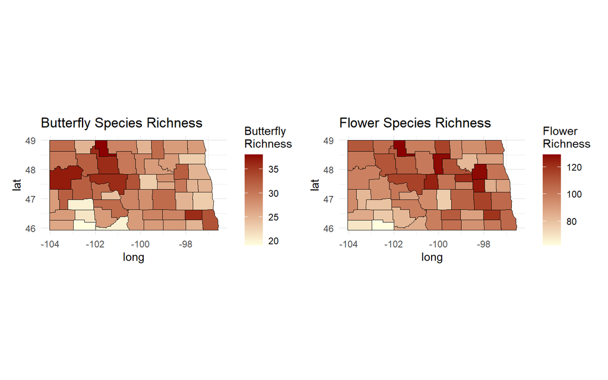

```r
library(dplyr)
library(ggplot2)
library(maps)
library(patchwork)

## Butterfly richness

butterfly_richness <- occurrence_data %>%
  filter(
    kingdom == "Animalia",
    occurrenceStatus == "present",
    taxonRank == "species"
  ) %>%
  left_join(
    event_data_core %>%
      select(eventID, county),
    by = "eventID"
  ) %>%
  group_by(county) %>%
  summarise(species_richness = n_distinct(scientificName))

butterfly_richness$county <- dplyr::recode(
  butterfly_richness$county,
  "LaMoure" = "La Moure",
  "McHenry" = "Mchenry",
  "McIntosh" = "Mcintosh",
  "McKenzie" = "Mckenzie",
  "McLean" = "Mclean"
)

## Flower richness

flower_richness <- occurrence_data %>%
  filter(
    kingdom == "Plantae",
    is.na(individualCount),
    occurrenceStatus == "present",
    taxonRank == "species"
  ) %>%
  left_join(
    event_data_core %>%
      select(eventID, county),
    by = "eventID"
  ) %>%
  group_by(county) %>%
  summarise(species_richness = n_distinct(scientificName))

flower_richness$county <- dplyr::recode(
  flower_richness$county,
  "LaMoure" = "La Moure",
  "McHenry" = "Mchenry",
  "McIntosh" = "Mcintosh",
  "McKenzie" = "Mckenzie",
  "McLean" = "Mclean"
)

## Map base

nd_map <- map_data("county", region = "north dakota")
nd_map$county <- tools::toTitleCase(gsub("north dakota,", "", nd_map$subregion))

## Join data

butterfly_map <- left_join(nd_map, butterfly_richness, by = "county")
flower_map <- left_join(nd_map, flower_richness, by = "county")

## Butterfly plot

p1 <- ggplot(butterfly_map, aes(long, lat, group = group, fill = species_richness)) +
  geom_polygon(color = "black", linewidth = 0.2) +
  coord_fixed(1.3) +
  scale_fill_gradient(
    low = "lightyellow",
    high = "darkred",
    name = "Butterfly\nRichness",
    na.value = "white"
  ) +
  theme_minimal() +
  labs(
    title = "Butterfly Species Richness"
  )

## Flower plot

p2 <- ggplot(flower_map, aes(long, lat, group = group, fill = species_richness)) +
  geom_polygon(color = "black", linewidth = 0.2) +
  coord_fixed(1.3) +
  scale_fill_gradient(
    low = "lightyellow",
    high = "darkred",
    name = "Flower\nRichness",
    na.value = "white"
  ) +
  theme_minimal() +
  labs(
    title = "Flower Species Richness"
  )

p1 + p2
```

## Scatterplot butterfly v flower richness

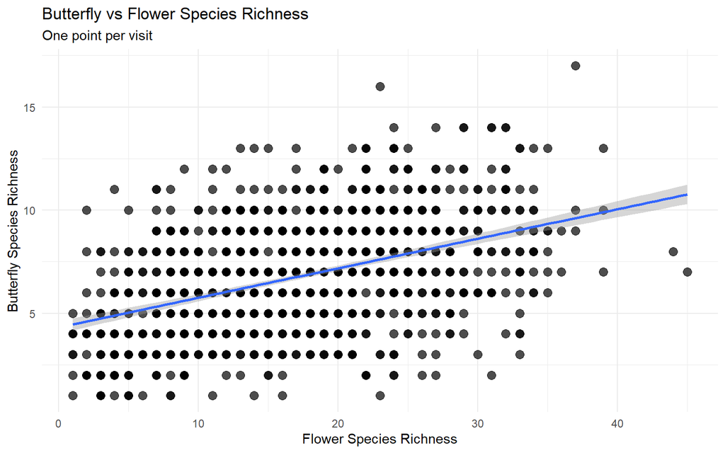

```r
library(dplyr)
library(ggplot2)

butterfly_richness <- occurrence_data %>%
  filter(
    kingdom == "Animalia",
    occurrenceStatus == "present",
    taxonRank == "species"
  ) %>%
  left_join(
    event_data_core %>%
      select(eventID, parentEventID),
    by = "eventID"
  ) %>%
  group_by(parentEventID) %>%
  summarise(butterfly_richness = n_distinct(scientificName), .groups = "drop")

flower_richness <- occurrence_data %>%
  filter(
    kingdom == "Plantae",
    occurrenceStatus == "present",
    taxonRank == "species"
  ) %>%
  left_join(
    event_data_core %>%
      select(eventID, parentEventID),
    by = "eventID"
  ) %>%
  group_by(parentEventID) %>%
  summarise(flower_richness = n_distinct(scientificName), .groups = "drop")

richness_data <- left_join(
  butterfly_richness,
  flower_richness,
  by = "parentEventID"
)

ggplot(richness_data, aes(x = flower_richness, y = butterfly_richness)) +
  geom_point(size = 3, alpha = 0.7) +
  geom_smooth(method = "lm", se = TRUE) +
  theme_minimal() +
  labs(
    x = "Flower Species Richness",
    y = "Butterfly Species Richness",
    title = "Butterfly vs Flower Species Richness",
    subtitle = "One point per visit"
  )
```

## Heatmap

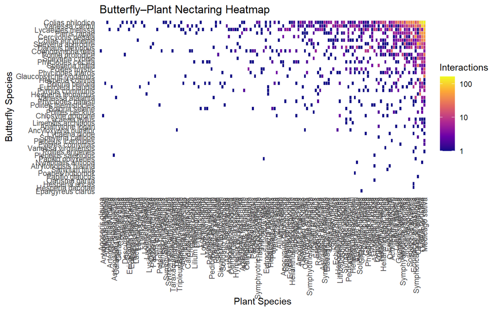

```r
library(dplyr)
library(ggplot2)

interaction_data <- butterfly_plant_interactions %>%
  filter(
    relationshipOfResource == "nectaring"
  ) %>%
  left_join(
    occurrence_data %>%
      select(occurrenceID, butterfly = scientificName),
    by = c("resourceID" = "occurrenceID")
  ) %>%
  left_join(
    occurrence_data %>%
      select(occurrenceID, plant = scientificName),
    by = c("relatedResourceID" = "occurrenceID")
  ) %>%
  filter(!is.na(butterfly), !is.na(plant)) %>%
  count(butterfly, plant, sort = TRUE)

butterfly_order <- interaction_data %>%
  group_by(butterfly) %>%
  summarise(total = sum(n)) %>%
  arrange(total) %>%
  pull(butterfly)

plant_order <- interaction_data %>%
  group_by(plant) %>%
  summarise(total = sum(n)) %>%
  arrange(total) %>%
  pull(plant)

interaction_data$butterfly <- factor(interaction_data$butterfly, levels = butterfly_order)
interaction_data$plant <- factor(interaction_data$plant, levels = plant_order)

ggplot(interaction_data, aes(x = plant, y = butterfly, fill = n)) +
  geom_tile(color = "gray90") +
  scale_fill_viridis_c(option = "plasma", trans = "log10") +
  theme_minimal() +
  theme(
    axis.text.x = element_text(angle = 90, hjust = 1, vjust = 0.5),
    panel.grid = element_blank()
  ) +
  labs(
    x = "Plant Species",
    y = "Butterfly Species",
    fill = "Interactions",
    title = "Butterfly–Plant Nectaring Heatmap"
  )
```

## Map for a species

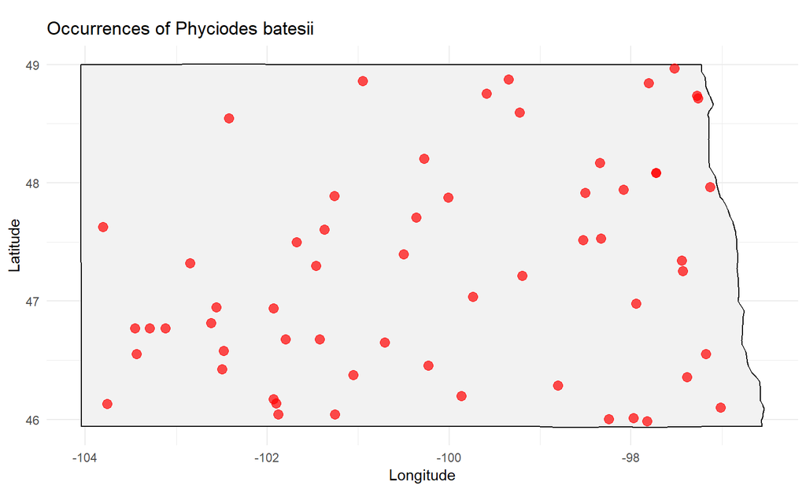

```r
library(dplyr)
library(ggplot2)
library(maps)

target_species <- "Phyciodes batesii"

species_points <- occurrence_data %>%
  filter(scientificName == target_species) %>%
  left_join(
    event_data_core %>%
      select(eventID, decimalLongitude, decimalLatitude),
    by = "eventID"
  ) %>%
  distinct(decimalLongitude, decimalLatitude)

nd_map <- map_data("state")

ggplot() +
  geom_polygon(
    data = subset(nd_map, region == "north dakota"),
    aes(long, lat, group = group),
    fill = "gray95",
    color = "black"
  ) +
  geom_point(
    data = species_points,
    aes(decimalLongitude, decimalLatitude),
    color = "red",
    size = 3,
    alpha = 0.7
  ) +
  coord_fixed(1.3) +
  theme_minimal() +
  labs(
    title = paste("Occurrences of", target_species),
    x = "Longitude",
    y = "Latitude"
  )
```